# Course Intro and R/RStudio Basics

## Agenda

- Course overview and mechanics
- R Basics
- R and RStudio Workflow Basics
- (Recommended): STAT 345 Homework One (no submission)
- Readings: R4DS Chapters 4, 6, 8, 27, 29, and 30
- Other sources:
  - [Quick-R Data Management](https://www.statmethods.net/management/index.html)
  - [Quick-R Data Input](https://www.statmethods.net/input/index.html)

## Course overview

- Focus on RStudio, Tableau, and Python
  - We’ll be moving quickly through a lot of material
- Lectures/demonstrations on core concepts
  - We will not be covering everything you need to learn in class
  - Course materials and additional reading materials posted on Canvas
- Homework to extend on core concepts
  - There will be a significant amount of reading and searching for solutions
  - Get used to using online resources (R-bloggers, stackexchange, etc.)
- Student presentations on advancements/improvements/additional resources
  - Intended to cover a wider variety of modern approaches not typically found in textbooks and improve communication skills

## The R console

Basic interaction with R is by typing in the **console**, a.k.a. **terminal** or **command-line**

You type in commands, R gives back answers (or errors)

Menus and other graphical interfaces are extras built on top of the console (such as RStudio!)

## The RStudio IDE

RStudio is a integrated development environment for R. A basic configuration includes four panes:

- Scripts, workbooks, and presentation files
- Environment, History, and more
- Console, terminal, and debugging tools
- File browser, plot viewer, and package selector

## Variables built into R

R has a small number of built-in constants. The following constants are available:

- `LETTERS`: the 26 upper-case letters of the Roman alphabet;
- `letters`: the 26 lower-case letters of the Roman alphabet;
- `month.abb`: the three-letter abbreviations for the English month names;
- `month.name`: the English names for the months of the year;
- `pi`: the ratio of the circumference of a circle to its diameter.

These are implemented as variables in the base namespace taking appropriate values.

## Creating new variables

Variables in R must start with a letter, and contain only letters, numbers, `.`, and `_`

Most variables are created with the **assignment operator**, `<-` or `=`

```r
approx_pi <- 22/7
approx_pi
## [1] 3.142857
diameter_in_cubits = 10
approx_pi*diameter_in_cubits
## [1] 31.42857
```

## Creating New Variables

The assignment operator also changes values:

```r
circumference_in_cubits <- approx_pi*diameter_in_cubits
circumference_in_cubits
## [1] 31.42857
circumference_in_cubits <- 30
circumference_in_cubits
## [1] 30
```

## The workspace

What names have you defined values for?

```r
ls()
## [1] "approx_pi"               "circumference_in_cubits"
## [3] "diameter_in_cubits"
objects()
## [1] "approx_pi"               "circumference_in_cubits"
## [3] "diameter_in_cubits"
```

Getting of variables:

```r
rm("circumference_in_cubits")
ls()
## [1] "approx_pi"          "diameter_in_cubits"
```

Also, see the “Environment” tab!

## Abstraction

Using names and variables makes code: easier to design, easier to debug, less prone to bugs, easier to improve, and easier for others to read

Best practice: use “snake case” (variable_name)

Avoid “magic constants”; use named variables!

## Data types

- character: R does not distinguish between individual characters and strings
- numeric: “double” in other languages
  - integer: add “L” to the end of the number to coerce an integer (`5L` is 5 as an integer)
  - complex: add “i” to the end of the number to coerce a complex number (`5i` is 5 as a complex number)
- boolean: TRUE/FALSE, common in control structures
- NA: the typical missing value indicator in R
- factor: nominal and ordinal objects

## Data types

- `typeof()` and `str()` functions return the type of object
- `is.`*foo*`()` functions return Booleans for whether the argument is of type *foo*
- `as.`*foo*`()` (tries to) “cast” its argument to type *foo* — to translate it sensibly into a *foo*-type value

## Data types

```r
typeof(5/6)
## [1] "double"
as.character(5/6)
## [1] "0.833333333333333"
as.numeric(as.character(5/6))
## [1] 0.8333333
6*as.numeric(as.character(5/6))
## [1] 5
5/6 == as.numeric(as.character(5/6))
## [1] FALSE
```

## Factors

- We can tell R that a variable is nominal by making it a factor.
- The factor stores the nominal values as a vector of integers in the range [1…k] (where k is the number of unique values in the nominal variable), and an internal vector of character strings (the original values) mapped to these integers.
- `factor(x)` casts an object `x` as a nominal variable
- `ordered(x)` casts an object `x` as an ordinal variable (alphabetically!)

## Operators in R

- `+`: addition
- `-`: subtraction
- `*`: multiplication
- `/`: division
- `^` or `**`: exponentiation
- `x%%y`: modulus (x mod y)
- `x%/%y%`: integer division

## Operators in R

- `<`: less than
- `<=`: less than or equal to
- `>`: greater than
- `>=`: greater than or equal to
- `==`: exactly equal to
- `!=`: not equal to
- `!x`: not x
- `x|y`: x OR y
- `x&y`: x AND y
- `isTRUE(x)`: test if X is TRUE

## Functions in R

Some common numeric functions:

- `abs(x)`: absolute value
- `sqrt(x)`: square root
- `ceiling(x)`: ceiling(3.475) is 4
- `floor(x)`: floor(3.475) is 3
- `trunc(x)`: trunc(5.99) is 5
- `round(x, digits=n)`: round(3.475, digits=2) is 3.48
- `signif(x, digits=n)`: signif(3.475, digits=2) is 3.5
- `cos(x), sin(x), tan(x)`: also acos(x), cosh(x), acosh(x), etc.
- `log(x)`: natural logarithm
- `log10(x)`: common logarithm
- `exp(x)`: e^x

## Functions in R

Some common character functions:

- `substr(x, start=n1, stop=n2)`: Extract or replace substrings in a character vector.
- `grep(pattern, x , ignore.case=FALSE, fixed=FALSE)`: Search for pattern in x. If fixed =FALSE then pattern is a regular expression. If fixed=TRUE then pattern is a text string. Returns matching indices.
- `sub(pattern, replacement, x, ignore.case =FALSE, fixed=FALSE)`: Find pattern in x and replace with replacement text.
- `strsplit(x, split)`: Split the elements of character vector x at split.
- `paste(..., sep="")`: Concatenate strings after using sep string to seperate them.
- `toupper(x)`: Uppercase
- `tolower(x)`: Lowercase

## Functions in R

Some common statistical functions:

- `mean(x, trim=0,na.rm=FALSE)`: mean of object x
- `sd(x)`: standard deviation of object(x). also look at `var(x)` for variance and `mad(x)` for median absolute deviation.
- `median(x)`: median
- `quantile(x, probs)`: quantiles where `x` is the numeric vector whose quantiles are desired and `probs` is a numeric vector with probabilities in [0,1].
- `range(x)`: range
- `sum(x)`: sum
- `diff(x, lag=1)`: lagged differences, with lag indicating which lag to use
- `min(x)`: minimum
- `max(x)`: maximum
- `scale(x, center=TRUE, scale=TRUE)`: column center or standardize a matrix.

## Functions in R

Some other useful functions:

- `seq(from , to, by)`: generate a sequence
- `rep(x, n)`: repeat `x` n times
- `cut(x,n)`: divide continuous variable `x` in factor with n levels

## User defined functions

The structure of a function:

```r
#Function to do "statements"
#Inputs: arg1, a data structure; arg2, a boolean
#Outputs: the thing we want
myfunction <- function(arg1, arg2, ... ){
  statements #Comments internally to explain the process (typically to yourself in 6 months)
  return(object)
}
```

- function name: same rules as for variables
- inputs/arguments: inside the `function()` function
  - Can include defaults for arguments
- outputs/return values: specified in the `return()` function
- comments: not required by R, but recommended
  - One-line description of purpose; listing of arguments; listing of outputs; internal comments

## What should be a function?

- Things you’re going to re-run, especially if it will be re-run with changes
- Chunks of code you keep highlighting and hitting return on
- Chunks of code which are small parts of bigger analyses
- Chunks which are very similar to other chunks

## Example function

```r
# Function example - get measures of central tendency and spread for a numeric vector x.
# Inputs: x, a numeric vector; npar, boolean if nonparametric measures are desired; print, boolean if results should be printed to the console.
# Outputs: a list object with center and spread statistics

mysummary <- function(x,npar=TRUE,print=TRUE) {
  if (!npar) {
    center <- mean(x); spread <- sd(x)
  } else {
    center <- median(x); spread <- mad(x)
  }
  if (print & !npar) {
    cat("Mean=", center, "\n", "SD=", spread, "\n")
  } else if (print & npar) {
    cat("Median=", center, "\n", "MAD=", spread, "\n")
  }
  result <- list(center=center,spread=spread)
  return(result)
}
```

## Example function

```r
# invoking the function
set.seed(1234)
x <- rpois(500, 4)
y <- mysummary(x)
## Median= 4
##  MAD= 1.4826

z <- mysummary(x, npar=FALSE, print=FALSE)
z
## $center
## [1] 4.052
##
## $spread
## [1] 2.01927
```

## Control structures

- if-else:
  - `if (cond) expr`
  - `if (cond) {expr1 expr2}`
  - `if (cond) expr1 else expr2`
- for: `for (var in seq) expr`
- while: `while (cond) expr`
- switch: `switch(expr, ...)`
- ifelse: `ifelse(test, yes, no)`

## Example function

```r
# Function to compute the transpose of a matrix (a poor alternative to built-in t() function)
# Inputs: a matrix x
# Outputs: a matrix
mytrans <- function(x) {
  if (!is.matrix(x)) {
    warning("argument is not a matrix: returning NA")
    return(NA_real_)
  }
  y <- matrix(1, nrow=ncol(x), ncol=nrow(x))
  for (i in 1:nrow(x)) {
    for (j in 1:ncol(x)) {
      y[j,i] <- x[i,j]
    }
  }
return(y)
}
```

## Another example function

```r
require(stats)
centre <- function(x, type) {
  switch(type,
         mean = mean(x),
         median = median(x),
         trimmed = mean(x, trim = .1))
}
x <- rcauchy(10)
centre(x, "mean"); centre(x, "median"); centre(x, "trimmed")
## [1] -0.6865606
## [1] -0.6573968
## [1] -0.6983059
```

## Data structures

- Vectors - R’s basic data structure; incredibly common and useful
- Arrays - multi-dimensional vectors; uncommon
- Matrices - numeric, 2D array; particularly useful for some statistical applications
- Lists - sequence of values, *not* necessarily all of the same type
- Data Frames - basically a list of vectors; we’ll spend most of our time here

## First data structure: vectors

A **vector** is a sequence of values, all of the same type

```r
x <- c(7, 8, 10, 45)
x
## [1]  7  8 10 45
is.vector(x)
## [1] TRUE
x2 <- c("a", "b", "c"); x2
## [1] "a" "b" "c"
is.vector(x2)
## [1] TRUE
```

`c()` function returns a vector containing all its arguments in order

`x[1]` is the first element, `x[4]` is the 4th element of x `x2[-4]` is a vector containing all but the fourth element of x2

## First data structure: vectors

`vector(length=6)` returns an empty vector of length 6; helpful for filling things up later

```r
weekly.hours <- vector(length=5)
weekly.hours[5] <- 8
weekly.hours
## [1] 0 0 0 0 8
```

## Vector arithmetic

Operators apply to vectors “pairwise” or “elementwise”:

```r
#x <- c(7, 8, 10, 45)
y <- c(-7, -8, -10, -45)
x+y
## [1] 0 0 0 0
x*y
## [1]   -49   -64  -100 -2025
```

## Recycling

**Recycling** repeat elements in shorter vector when combined with longer

```r
x + c(-7,-8)
## [1]  0  0  3 37
x^c(1,0,-1,0.5)
## [1] 7.000000 1.000000 0.100000 6.708204
```

Single numbers are vectors of length 1 for purposes of recycling:

```r
2*x
## [1] 14 16 20 90
```

## Vector comparisons

To compare whole vectors, best to use `identical()` or `all.equal()`:

```r
x == -y
## [1] TRUE TRUE TRUE TRUE
identical(x,-y)
## [1] TRUE
identical(c(0.5-0.3,0.3-0.1),c(0.3-0.1,0.5-0.3))
## [1] FALSE
all.equal(c(0.5-0.3,0.3-0.1),c(0.3-0.1,0.5-0.3))
## [1] TRUE
```

## Functions on vectors

Lots of functions take vectors as arguments:

- `mean()`, `median()`, `sd()`, `var()`, `max()`, `min()`, `length()`, `sum()`: return single numbers
- `sort()` returns a new vector
- `hist()` takes a vector of numbers and produces a histogram, a highly structured object, with the side-effect of making a plot
- Similarly `ecdf()` produces a cumulative-density-function object
- `summary()` gives a five-number summary of numerical vectors
- `any()` and `all()` are useful on Boolean vectors

## Addressing vectors

Vector of indices:

```r
x[c(2,4)]
## [1]  8 45
```

Vector of negative indices

```r
x[c(-1,-3)]
## [1]  8 45
```

## Boolean vectors

Boolean vector:

```r
x[x>9]
## [1] 10 45
y[x>9]
## [1] -10 -45
```

`which()` turns a Boolean vector into a vector of TRUE indices:

```r
places <- which(x > 9)
places
## [1] 3 4
y[places]
## [1] -10 -45
```

## Named components

You can give names to elements or components of vectors

```r
names(x) <- c("v1","v2","v3","fred")
names(x)
## [1] "v1"   "v2"   "v3"   "fred"
x[c("fred","v1")]
## fred   v1
##   45    7
```

`names(x)` is just another vector (of characters)

## Arrays

A generally useful structure for programming, not so much for common statistical or data science techniques

## Matrices

- In R, a matrix is a specialization of a 2D array
- All columns in a matrix must have the same mode(numeric, character, etc.) and the same length. The general format is

```r
mymatrix <- matrix(vector, nrow=r, ncol=c, byrow=FALSE,
   dimnames=list(char_vector_rownames, char_vector_colnames))
```

- `byrow=TRUE` indicates that the matrix should be filled by rows (default is by columns)
- `dimnames` provides optional labels for the columns and rows.

## Matrices

- Element-wise operations with the usual arithmetic and comparison operators (e.g., `factory/3`)
- Compare whole matrices with `identical(x,y)` or `all.equal(x,y)`
- Special operator for multiplication: `x%*%y`
- Transpose: `t(x)`
- Diagonal, determinant, and inverse: `diag(x)`, `det(x)`, `solve(x)`
- Identify rows, columns, or elements using subscripts: `x[2:4, 1:3]`

## Lists

- An ordered collection of objects (components). A list allows you to gather a variety of (possibly unrelated) objects under one name.
  - Most of what you can do with vectors you can also do with lists
- Accessing elements:
  - Can use `[ ]` as with vectors
  - Use `[[ ]]`, but only with a single index
    - `[[ ]]` drops names and structures, `[ ]` does not
  - Use `$` with named elements (also drops names and structures)
- Lists are super useful, but behave oddly when you don’t anticipate them

## Data frames

- Dataframe = the classic data table, \(n\) rows for cases, \(p\) columns for variables
- Lots of the really-statistical parts of R presume data frames
- Not just a matrix because *columns can have different types*
- Many matrix functions also work for dataframes (`rowSums()`, `summary()`, `apply()`)
  - no matrix multiplying dataframes, even if all columns are numeric

## Data frames

```r
library(datasets)
states <- data.frame(state.x77, abb=state.abb, region=state.region, division=state.division)
```

- `data.frame()` is combining here a pre-existing matrix (`state.x77`), a vector of characters (`state.abb`), and two vectors of qualitative categorical variables (**factors**; `state.region`, `state.division`)
- Column names are preserved or guessed if not explicitly set

## with()

- What percentage of literate adults graduated HS?

```r
head(100*(states$HS.Grad/(100-states$Illiteracy)))
## [1] 42.18590 67.71574 59.16497 40.67278 63.29626 64.35045
```

- `with()` takes a data frame and evaluates an expression “inside” it:

```r
with(states, head(100*(HS.Grad/(100-Illiteracy))))
## [1] 42.18590 67.71574 59.16497 40.67278 63.29626 64.35045
```

## Data arguments

Many functions take `data` arguments, and look variables up in that data frame:

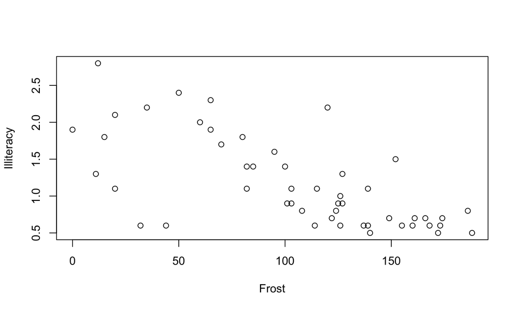

```r
plot(Illiteracy~Frost, data=states)
```

## Workflow: scripts

- Each of the lines of code we’ve seen so far can be run directly in the console
- To keep these lines of code organized (and easily reproducible), we can use the script editor
- To use the script editor. Open it up either by clicking the File menu, and selecting New File, then R script, or using the keyboard shortcut Cmd/Ctrl + Shift + N.
- Can run expressions directly from the script editor using Cmd/Ctrl + Enter
  - Run the whole script with Cmd/Ctrl + Shift + S
- Start scripts with the packages you need (`library` or `require` calls only, not `install.packages` or `setwd`)

## Workflow: what is real?

- Your working environment is a product of the code/scripts you’ve run and your data files
  - You can recreate the environment by re-running your scripts
  - Wickham recommends you set RStudio to not preserve your workspace between sessions (see R4DS 8.1)
- Checking to see if your scripts have captured everything is important!
  - Press Cmd/Ctrl + Shift + F10 to restart RStudio
  - Press Cmd/Ctrl + Shift + S to rerun the current script

## Workflow: the working directory

- The `STAT345-hw-01.docx` file on Canvas recommends setting up a reasonable file structure for the class
  - This will typically be sufficient for a class (like STAT 763), or for small projects
- By default, R will initially set a working directory based on the location of the file in your computer
  - Saving files to a file structure, then opening the file from that location is a simple approach
- You can set the working directory using `setwd()`
  - Shouldn’t be needed with this approach
  - Use relative paths throughout your code (no absolute paths)
  - Use forward slashes (Linux/Mac style) in your paths, even if using Windows

## Workflow: projects

- An even better approach, particularly when working with many files, is to set up a Project
  - File > New Project > New Directory > Empty Project
  - Set the directory name appropriately, and make it a subdirectory of a sensible directory
- When you quit RStudio and re-open the project, RStudio gives you:
  - The same working directory you expect
  - Your complete command history
  - All the files that were open
  - Ideally a fresh environment (if you aren’t preserving your workspace as noted before)

## Workflow: R Markdown

- Single framework for combining code, results, and written descriptions
- Fully reproducible with many output formats
- R Markdown can be used for
  - communicating results
  - collaborating with other statisticians/data scientists
  - a modern-day lab notebook
- R Markdown Cheat Sheets:
  - Help > Cheatsheets > R Markdown Cheat Sheet
  - Help > Cheatsheets > R Markdown Reference Guide

## R Markdown: basics

- An R Markdown file (.Rmd) contains three types of content:
  - An optional `YAML` header (surrounded by `---`)
  - Chunks of R code (surrounded by `` ``` ``)
  - Text with simple formatting (`# heading` and `_italics_`)
- Code and output are woven together
  - Press the play button on a code chunk (or Cmd/Ctrl + Shift + Enter) to run the code and display the results inline
  - Create a report by clicking “Knit”
    - Or with Cmd/Ctrl + Shift + K
    - Or with `rmarkdown::render("1-example.Rmd")` in code

## R Markdown: text formatting

- Help > Markdown Quick Reference
- Text formatting:
  - `*italic*` or `_italic_`
  - `**bold**` or `__bold__`
  - code
  - `superscript^2^` and `subscript~2~`
- Headings:
  - `# 1st Level Header`
  - `## 2nd Level Header`
  - `## 3rd Level Header`
- Lots of options for formatting lists and tables

## R Markdown: code chunks

- Running code in an R Markdown document requires “code chunks”
  - Cmd/Ctrl + Alt + I
  - “Insert” button in the editor toolbar
  - Typing the chunk delimeters `` ```{r} `` and `` ``` ``
- Chunks can be given names `` ```{r by-name} ``
  - Easier navigation
  - graphics produced by chunks will be named more usefully
  - can cache chunks for long-running code

## R Markdown: chunk options

- There are a whole lot of them: http://yihui.name/knitr/options/
- The primary ones are:
  - `eval = FALSE` - don’t evaluate code chunk (display code, but disable it)
  - `include = FALSE` - run code, don’t show code or results (good for setup)
  - `echo = FALSE` - run code, don’t show code, show results (good for hiding the code in reports)
  - `message = FALSE` and `warning = FALSE` - suppress messages or warnings in document
  - `results = 'hide'` hides printed output, `fig.show = 'hide'` hides plots
  - `error = TRUE` - render document even if code returns an error (good for debugging)

## R Markdown: tables

- You can print (typically) nicer tables in your documents:
  - Standard way: something like simply calling the dataframe

```r
mtcars[1:5,]
##                    mpg cyl disp  hp drat    wt  qsec vs am gear carb
## Mazda RX4         21.0   6  160 110 3.90 2.620 16.46  0  1    4    4
## Mazda RX4 Wag     21.0   6  160 110 3.90 2.875 17.02  0  1    4    4
## Datsun 710        22.8   4  108  93 3.85 2.320 18.61  1  1    4    1
## Hornet 4 Drive    21.4   6  258 110 3.08 3.215 19.44  1  0    3    1
## Hornet Sportabout 18.7   8  360 175 3.15 3.440 17.02  0  0    3    2
```

## R Markdown: nicer tables

Using the `knitr::kable` function:

```r
knitr::kable(
  mtcars[1:5,],
  caption = "A knitr table."
)
```

A knitr table.

|  | mpg | cyl | disp | hp | drat | wt | qsec | vs | am | gear | carb |
| --- | --- | --- | --- | --- | --- | --- | --- | --- | --- | --- | --- |
| Mazda RX4 | 21.0 | 6 | 160 | 110 | 3.90 | 2.620 | 16.46 | 0 | 1 | 4 | 4 |
| Mazda RX4 Wag | 21.0 | 6 | 160 | 110 | 3.90 | 2.875 | 17.02 | 0 | 1 | 4 | 4 |
| Datsun 710 | 22.8 | 4 | 108 | 93 | 3.85 | 2.320 | 18.61 | 1 | 1 | 4 | 1 |
| Hornet 4 Drive | 21.4 | 6 | 258 | 110 | 3.08 | 3.215 | 19.44 | 1 | 0 | 3 | 1 |
| Hornet Sportabout | 18.7 | 8 | 360 | 175 | 3.15 | 3.440 | 17.02 | 0 | 0 | 3 | 2 |

## R Markdown: caching

- Each knit of your R Markdown file starts from a clean slate
- You can use `cache = TRUE` in code chunks that take a long time
  - This is potentially dangerous, particularly if any files/code chunks upstream change
  - See R4DS 27.4.4 for more options (code dependencies, file dependencies, etc.)

## R Markdown: inline code

- You can embed code directly into your text with single gravs surrounding **r expr**
  - **expr** is whatever code whose results you want to display inline
  - This is particularly useful when referencing named objects
  - See R4DS 27.4.6 for reference to the `format()` function, or even better, Wickham’s custom `comma()` function

## R Markdown: YAML header

- “Yet Another Markup Language”
- You can control details/options for the whole document
  - R4DS 27.6 has some nice examples
  - There are a lot more options available (see https://bookdown.org/yihui/rmarkdown Chapter 3 for more)
    - You can set default table format to `kable` or `tibble` in pdfs
    - Allow “code-folding” in HTML documents

## R Markdown: document options

- `html_document`
- `pdf_document` - requires LaTeX (R will prompt)
- `word_document` - .docx files
- `odt_document` - OpenDocument Text
- `rtf_document` - Rich Text Format
- `md_document` - Markdown document (probably not useful directly)
- `github_document` - tailored .md document for GitHub
- `ioslides_presentation` - what these notes are using (alternative: .Rpres files)

Search `?rmarkdown::html_document` (or similar) for lots of options that you can set

## R Markdown: other “documents”

- Dashboards (R4DS 29.6): present related objects on one screen, perhaps interactively
- Websites (R4DS 29.8): yep, you could build a whole website in R
- htmlwidgets: client-side interactivity
- shiny: powerful, server-side interactive documents (we’ll cover these before Spring Break)